# Health Insurance analysis

```r
library(tidyverse)
library(readxl)
library(dplyr)
library(glue)
df <- read_xlsx("C:/College/Courses/SDM/Assignments/Health Insurance/Health-Insurance-analysis/HealthInsurance.xlsx", sheet = "Data")
```

### Data Exploration

```r
dft <- df
```

```r
dft
```

```
## # A tibble: 10,089 x 29
##    medexpense healthins   age female blackhisp income illnesses ssiratio
##         <dbl>     <dbl> <dbl>  <dbl>     <dbl>  <dbl>     <dbl>    <dbl>
##  1        595         1    74      1         0  94.5          0    0.150
##  2       1783         1    73      0         0  35.8          3    0.396
##  3        176         0    80      1         0   9.6          1    1
##  4       2437         1    70      0         0  38.7          5    0.207
##  5        330         0    91      0         0   8.72         3    0.537
##  6        922         1    82      1         0  43.6          2    0.326
##  7       1294         1    81      0         0  44.4          4    0.135
##  8        616         0    90      1         0  12            2    1
##  9       3708         1    73      0         0  24.7          1    0
## 10        701         0    79      1         0  13.5          3    1
## # ... with 10,079 more rows, and 21 more variables: lowincome <dbl>,
## #   firmsize <dbl>, firmlocation <dbl>, educyr <dbl>, private <dbl>,
## #   hisp <dbl>, black <dbl>, married <dbl>, verygood <dbl>, good <dbl>,
## #   fair <dbl>, poor <dbl>, poverty <dbl>, midincome <dbl>, msa <dbl>,
## #   prioritylist <dbl>, logmedexpense <dbl>, agesqrd <dbl>, logincome <dbl>,
## #   vgh <dbl>, fph <dbl>
```

Converting the binary columns to factors using list apply

```r
names <-c('healthins','female','lowincome','firmlocation','private','married','poverty','midincome','msa','prioritylist','vgh','fph','blackhisp','hisp','black')
dft[,names] <- lapply(dft[,names],factor)
```

```r
summary(dft)
```

```
##    medexpense    healthins      age        female   blackhisp     income
##  Min.   :    1   0:6233    Min.   :65.00   0:4267   0:8439    Min.   :  0.001
##  1st Qu.:  311   1:3856    1st Qu.:70.00   1:5822   1:1650    1st Qu.:  9.325
##  Median :  795             Median :74.00                      Median : 15.536
##  Mean   : 1288             Mean   :75.05                      Mean   : 22.122
##  3rd Qu.: 1685             3rd Qu.:80.00                      3rd Qu.: 27.524
##  Max.   :26375             Max.   :91.00                      Max.   :312.460
##    illnesses        ssiratio      lowincome    firmsize       firmlocation
##  Min.   :0.000   Min.   :0.0000   0:8198    Min.   : 0.0000   0:9463
##  1st Qu.:1.000   1st Qu.:0.2381   1:1891    1st Qu.: 0.0000   1: 626
##  Median :2.000   Median :0.5045             Median : 0.0000
##  Mean   :1.861   Mean   :0.5365             Mean   : 0.1405
##  3rd Qu.:3.000   3rd Qu.:0.9091             3rd Qu.: 0.0000
##  Max.   :9.000   Max.   :9.2506             Max.   :50.0000
##      educyr      private  hisp     black    married     verygood
##  Min.   : 0.00   0:3769   0:9393   0:9110   0:4403   Min.   :0.0000
##  1st Qu.:10.00   1:6320   1: 696   1: 979   1:5686   1st Qu.:0.0000
##  Median :12.00                                       Median :0.0000
##  Mean   :11.79                                       Mean   :0.2629
##  3rd Qu.:14.00                                       3rd Qu.:1.0000
##  Max.   :17.00                                       Max.   :1.0000
##       good             fair             poor         poverty  midincome
##  Min.   :0.0000   Min.   :0.0000   Min.   :0.00000   0:8441   0:6839
##  1st Qu.:0.0000   1st Qu.:0.0000   1st Qu.:0.00000   1:1648   1:3250
##  Median :0.0000   Median :0.0000   Median :0.00000
##  Mean   :0.3371   Mean   :0.1876   Mean   :0.06542
##  3rd Qu.:1.0000   3rd Qu.:0.0000   3rd Qu.:0.00000
##  Max.   :1.0000   Max.   :1.0000   Max.   :1.00000
##  msa      prioritylist logmedexpense       agesqrd       logincome
##  0:2700   0:1343       Min.   : 0.000   Min.   :4225   Min.   :-6.908
##  1:7389   1:8746       1st Qu.: 5.740   1st Qu.:4900   1st Qu.: 2.233
##                        Median : 6.678   Median :5476   Median : 2.743
##                        Mean   : 6.481   Mean   :5677   Mean   : 2.743
##                        3rd Qu.: 7.430   3rd Qu.:6400   3rd Qu.: 3.315
##                        Max.   :10.180   Max.   :8281   Max.   : 5.744
##  vgh      fph
##  0:4036   0:7553
##  1:6053   1:2536
##
##
##
##
```

We only have people who are aged above 65.

Combining multiple binary columns to one categorical column

“Why write more code when less code do work” - Kavin, 2021

```r
colSums((is.na(dft)))
```

```
##    medexpense     healthins           age        female     blackhisp
##             0             0             0             0             0
##        income     illnesses      ssiratio     lowincome      firmsize
##             0             0             0             0             0
##  firmlocation        educyr       private          hisp         black
##             0             0             0             0             0
##       married      verygood          good          fair          poor
##             0             0             0             0             0
##       poverty     midincome           msa  prioritylist logmedexpense
##             0             0             0             0             0
##       agesqrd     logincome           vgh           fph
##             0             0             0             0
```

```r
status_function <- function(status){
  if(nchar(status) > 1){
    if(status == "good"){
    val <- "good"
    }
    else if(status == "verygood"){
    val <- "verygood"
    }
    else if(status == "fair"){
    val <- "fair"
    }
    else if(status == "poor"){
    val <- "poor"
    }
    else{
    val <- "unknown"
    }
    return(val)
  }
}
```

```r
names <- c('verygood','good','fair','poor')
dft$status <- dft[,names] %>%  apply( 1, function(x) names(x)[as.logical(x)])
dft$status <- lapply(dft$status, function(x) ifelse(identical(x, character(0)), "unknown", x))
dft$status <-  as.factor(unlist(lapply(dft$status,FUN = status_function)))
```

filtering out ssi ratio > 1

```r
dft <- dft %>% filter(ssiratio < 1)
```

There is discrepancy in the data. It shows people with no health insurance have private insurance.

Keeping this data as we dont know which one is true. We will just include one or the other in the models.

```r
dft %>% filter(healthins == 0 & private == 1) %>% count()
```

```
## # A tibble: 1 x 1
##       n
##   <int>
## 1  2027
```

```r
dft %>% filter(status == "unknown") %>% count()
```

```
## # A tibble: 1 x 1
##       n
##   <int>
## 1  1309
```

```r
df <- subset(dft,select = -c(verygood,good,fair,poor,firmlocation,firmsize,black,hisp,married,educyr,poverty,midincome,msa,prioritylist,vgh,fph))
```

### EDA

Distribution of Dependent variable: Medical expense

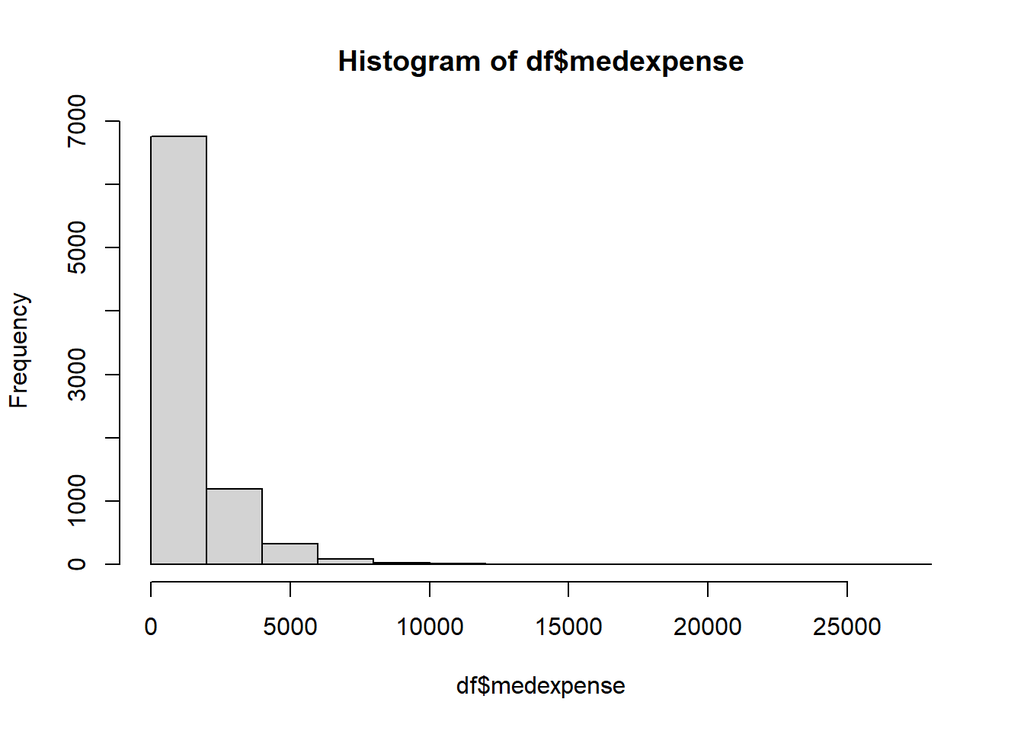

```r
hist(df$medexpense)
```

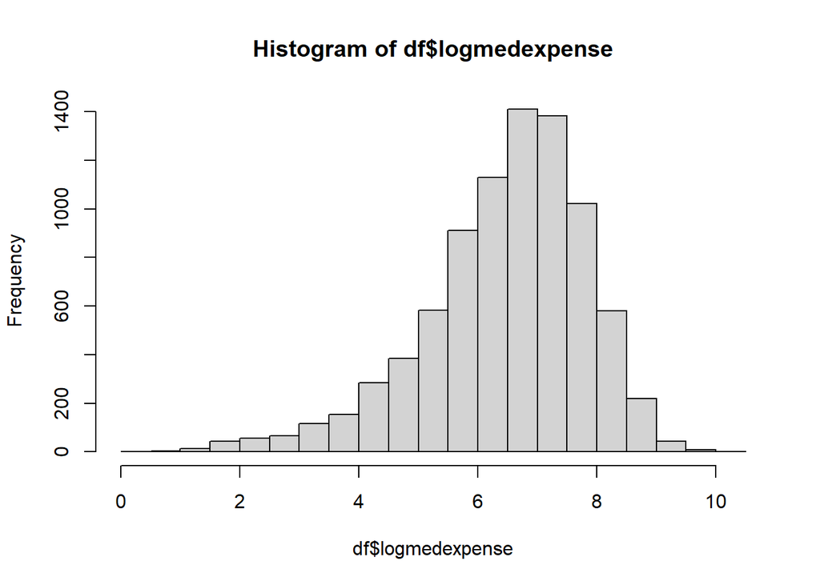

```r
hist(df$logmedexpense)
```

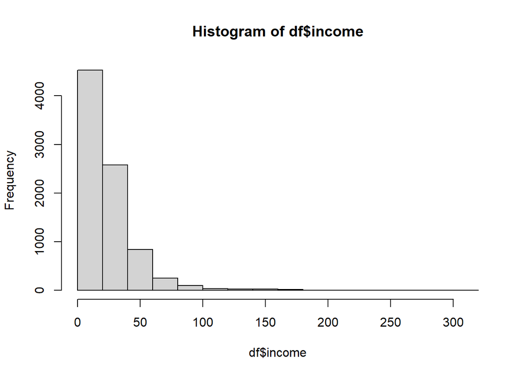

```r
hist(df$income)
```

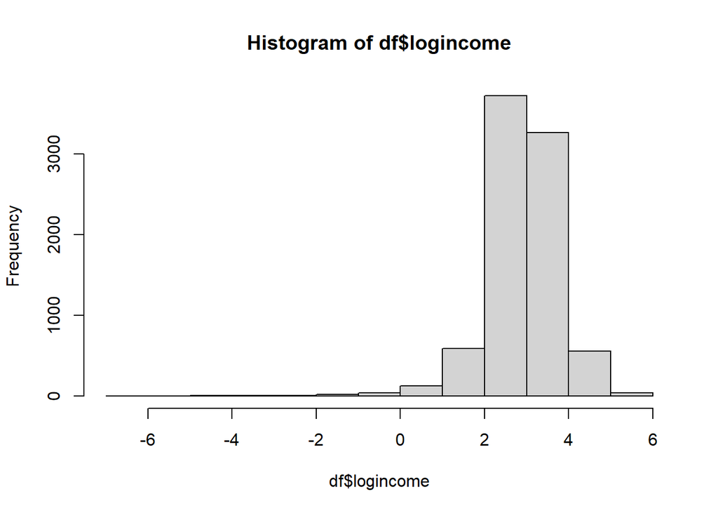

```r
hist(df$logincome)
```

How important is having health insurance?

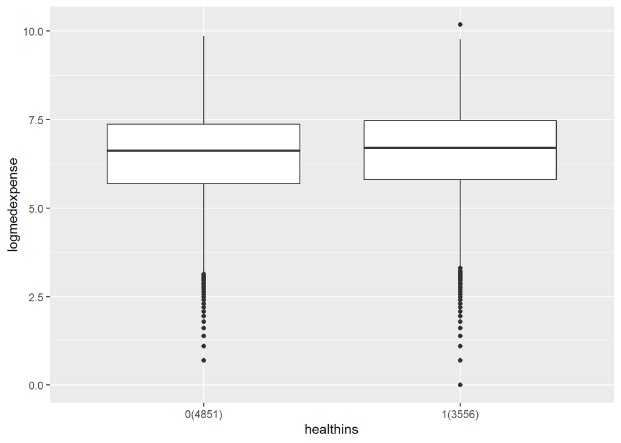

```r
df %>%
  add_count(healthins,name={"total"}) %>%
  mutate(healthins = glue("{healthins}({total})"),
         fct_reorder(healthins,medexpense)) %>%
  ggplot(aes(x = healthins,y=logmedexpense)) +
    geom_boxplot()
```

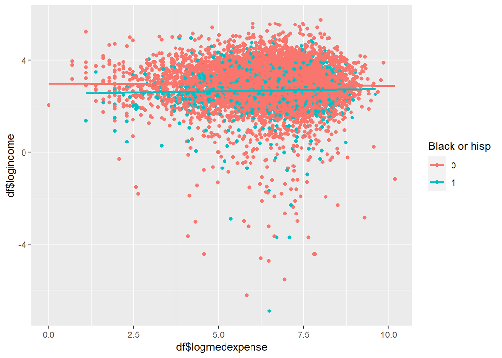

```r
ggplot() +
  aes(x = df$logmedexpense, y = df$logincome,color = df$blackhisp) +
  geom_point() + geom_smooth(method = "lm", se=FALSE) + labs(color = "Black or hisp")
```

Does health status matter?

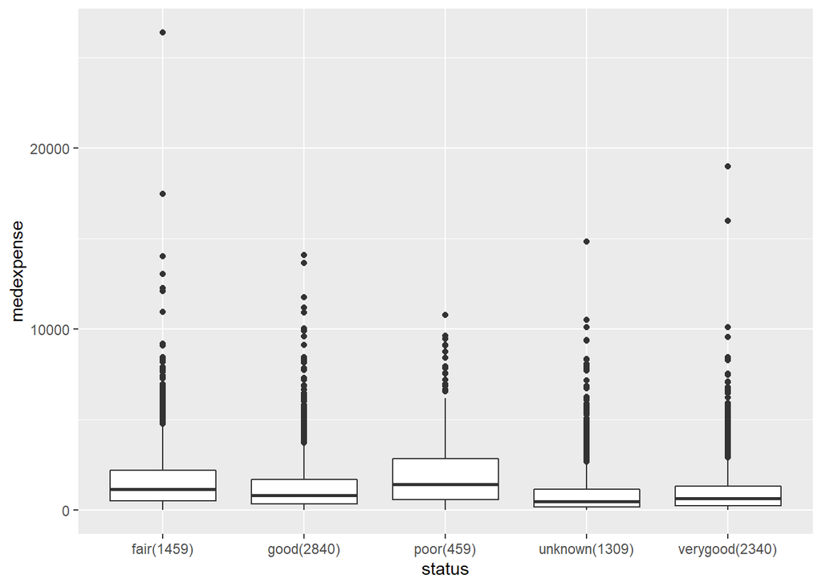

```r
df %>%
  add_count(status,name={"total"}) %>%
  mutate(status = glue("{status}({total})"),
         fct_reorder(status,medexpense)) %>%
  ggplot(aes(x = status,y=medexpense)) +
    geom_boxplot()
```

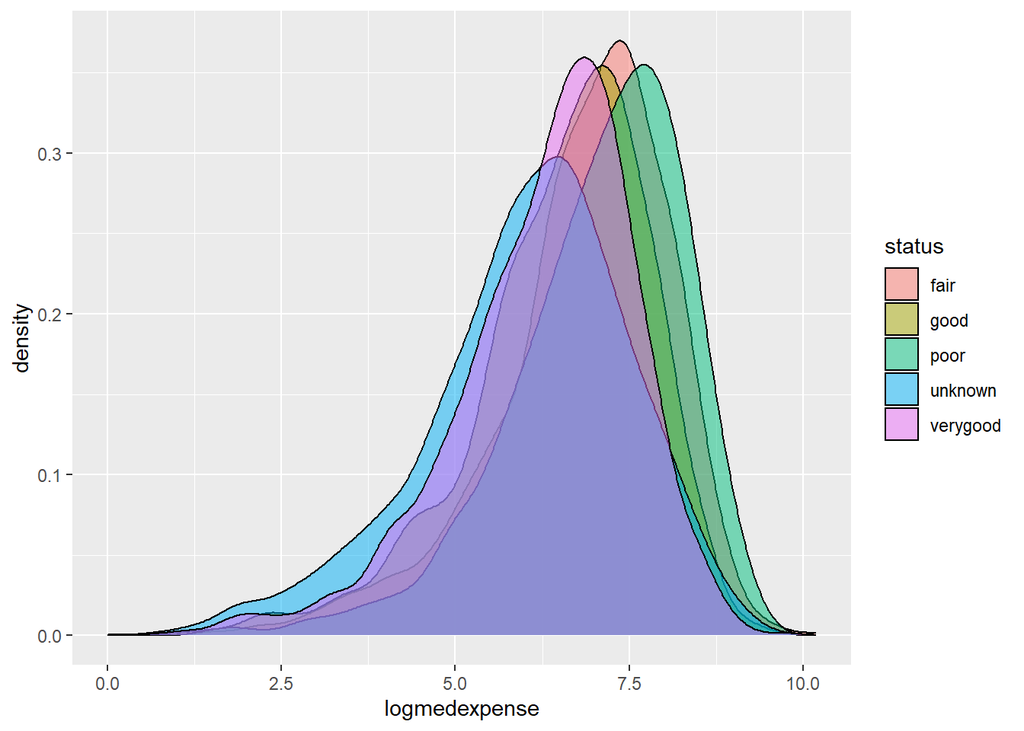

```r
df %>%
  ggplot(aes(logmedexpense,fill = status)) +
    geom_density(alpha = 0.5)
```

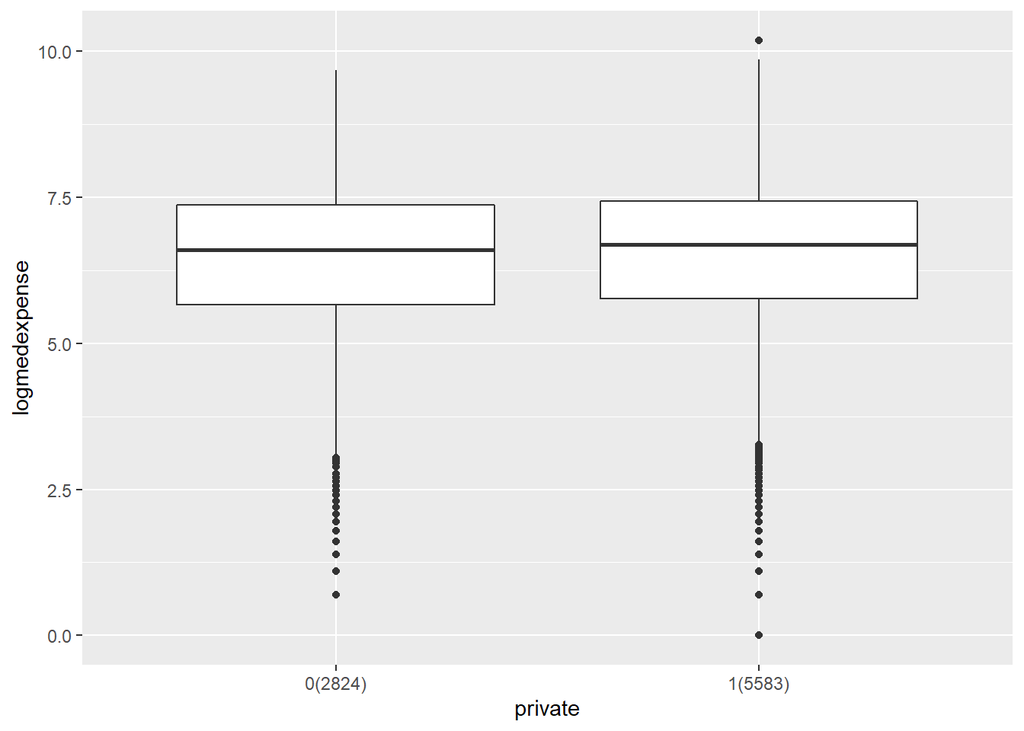

```r
df %>%
  add_count(private,name={"total"}) %>%
  mutate(private = glue("{private}({total})"),
         fct_reorder(private,medexpense)) %>%
  ggplot(aes(x = private,y=logmedexpense)) +
    geom_boxplot()
```

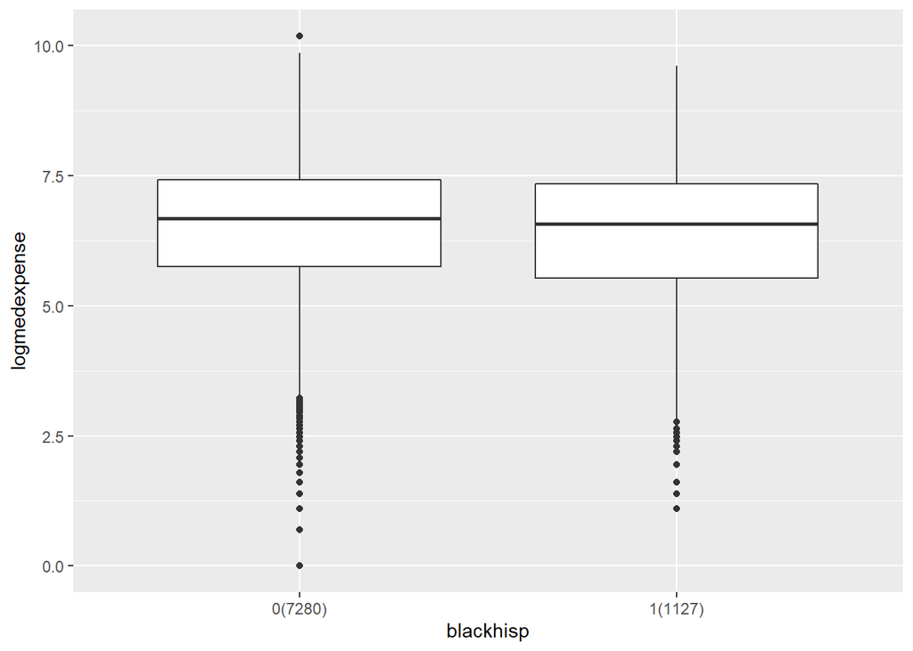

```r
df %>%
  add_count(blackhisp,name={"total"}) %>%
  mutate(blackhisp = glue("{blackhisp}({total})"),
         fct_reorder(blackhisp,medexpense)) %>%
  ggplot(aes(x = blackhisp,y=logmedexpense)) +
    geom_boxplot()
```

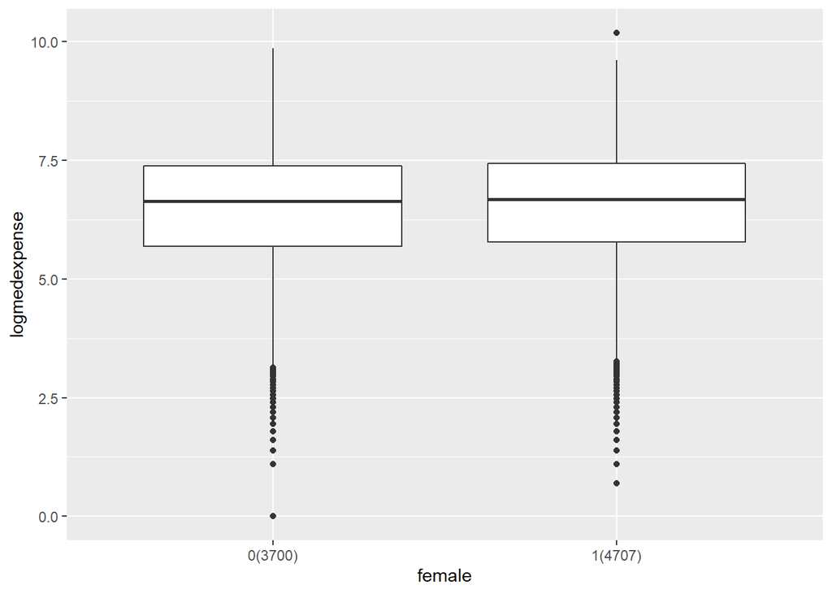

```r
df %>%
  add_count(female,name={"total"}) %>%
  mutate(female = glue("{female}({total})"),
         fct_reorder(female,medexpense)) %>%
  ggplot(aes(x = female,y=logmedexpense)) +
    geom_boxplot()
```

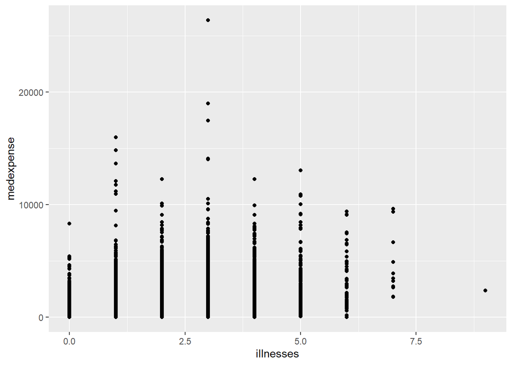

```r
df %>%
  ggplot(aes(illnesses, y = medexpense), ) +
  geom_point() + geom_smooth()
```

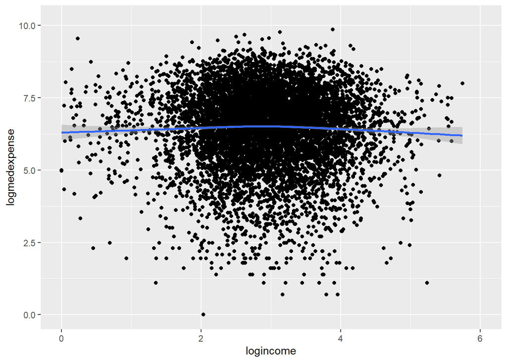

```r
df %>%
  ggplot(aes(logincome, y = logmedexpense)) +
  geom_point() + xlim(0,6) + geom_smooth()
```

```r
df %>% filter(ssiratio < 1) %>%
  filter(ssiratio < 0.5) %>% select(medexpense) %>% summarise(median(medexpense))
```

```
## # A tibble: 1 x 1
##   `median(medexpense)`
##                  <dbl>
## 1                 738.
```

Having medical expense based on firm size

```r
dft %>% filter(firmsize > 0) %>%
  summary()
```

```
##    medexpense     healthins      age        female  blackhisp     income
##  Min.   :   3.0   0:425     Min.   :65.00   0:455   0:611     Min.   :  1.517
##  1st Qu.: 230.2   1:289     1st Qu.:68.00   1:259   1:103     1st Qu.: 18.762
##  Median : 600.0             Median :70.00                     Median : 31.301
##  Mean   : 963.5             Mean   :71.87                     Mean   : 42.136
##  3rd Qu.:1292.2             3rd Qu.:74.00                     3rd Qu.: 53.611
##  Max.   :9934.0             Max.   :91.00                     Max.   :223.120
##    illnesses        ssiratio       lowincome    firmsize      firmlocation
##  Min.   :0.000   Min.   :0.00000   0:646     Min.   : 0.100   0:636
##  1st Qu.:1.000   1st Qu.:0.05413   1: 68     1st Qu.: 0.100   1: 78
##  Median :1.000   Median :0.19850             Median : 0.100
##  Mean   :1.529   Mean   :0.25364             Mean   : 1.983
##  3rd Qu.:2.000   3rd Qu.:0.38992             3rd Qu.: 0.100
##  Max.   :6.000   Max.   :0.99012             Max.   :50.000
##      educyr      private hisp    black   married    verygood
##  Min.   : 0.00   0:220   0:669   0:655   0:205   Min.   :0.0000
##  1st Qu.:12.00   1:494   1: 45   1: 59   1:509   1st Qu.:0.0000
##  Median :12.00                                   Median :0.0000
##  Mean   :12.89                                   Mean   :0.2885
##  3rd Qu.:16.00                                   3rd Qu.:1.0000
##  Max.   :17.00                                   Max.   :1.0000
##       good             fair             poor         poverty midincome msa
##  Min.   :0.0000   Min.   :0.0000   Min.   :0.00000   0:681   0:529     0:189
##  1st Qu.:0.0000   1st Qu.:0.0000   1st Qu.:0.00000   1: 33   1:185     1:525
##  Median :0.0000   Median :0.0000   Median :0.00000
##  Mean   :0.3361   Mean   :0.1429   Mean   :0.02381
##  3rd Qu.:1.0000   3rd Qu.:0.0000   3rd Qu.:0.00000
##  Max.   :1.0000   Max.   :1.0000   Max.   :1.00000
##  prioritylist logmedexpense      agesqrd       logincome      vgh     fph
##  0:124        Min.   :1.099   Min.   :4225   Min.   :0.4167   0:268   0:595
##  1:590        1st Qu.:5.439   1st Qu.:4624   1st Qu.:2.9319   1:446   1:119
##               Median :6.397   Median :4900   Median :3.4436
##               Mean   :6.181   Mean   :5198   Mean   :3.4324
##               3rd Qu.:7.164   3rd Qu.:5476   3rd Qu.:3.9817
##               Max.   :9.204   Max.   :8281   Max.   :5.4077
##       status
##  fair    :102
##  good    :240
##  poor    : 16
##  unknown :150
##  verygood:206
##
```

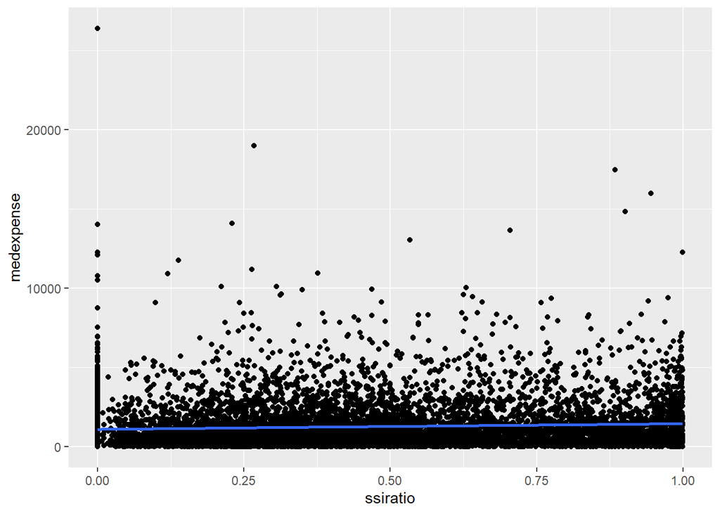

```r
df %>% filter(ssiratio < 1) %>%
  ggplot(aes(ssiratio, y = medexpense)) +
  geom_point() + geom_smooth()
```

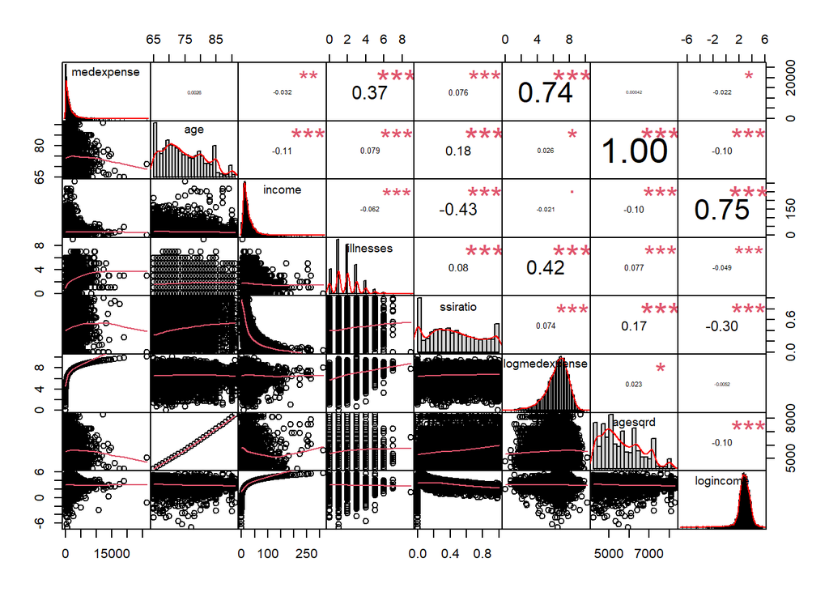

```r
nums <- unlist(lapply(df, is.numeric))
PerformanceAnalytics::chart.Correlation(df[,nums])
```

```r
ols_model1 <- lm(logmedexpense ~ healthins + private + female + blackhisp + income + status + agesqrd + illnesses,data=df)
summary(ols_model1)
```

```
##
## Call:
## lm(formula = logmedexpense ~ healthins + private + female + blackhisp +
##     income + status + agesqrd + illnesses, data = df)
##
## Residuals:
##     Min      1Q  Median      3Q     Max
## -6.2270 -0.6737  0.1391  0.8449  3.9325
##
## Coefficients:
##                  Estimate Std. Error t value Pr(>|t|)
## (Intercept)     5.965e+00  9.346e-02  63.820  < 2e-16 ***
## healthins1      9.418e-02  3.458e-02   2.724 0.006468 **
## private1        7.353e-04  3.604e-02   0.020 0.983722
## female1         5.846e-02  2.717e-02   2.152 0.031454 *
## blackhisp1     -1.920e-01  3.994e-02  -4.807 1.56e-06 ***
## income          6.300e-04  6.019e-04   1.047 0.295299
## statusgood     -1.485e-01  3.982e-02  -3.730 0.000193 ***
## statuspoor      4.838e-02  6.559e-02   0.738 0.460732
## statusunknown  -4.571e-01  4.812e-02  -9.498  < 2e-16 ***
## statusverygood -2.486e-01  4.201e-02  -5.917 3.40e-09 ***
## agesqrd        -2.019e-05  1.360e-05  -1.485 0.137674
## illnesses       4.073e-01  1.086e-02  37.487  < 2e-16 ***
## ---
## Signif. codes:  0 '***' 0.001 '**' 0.01 '*' 0.05 '.' 0.1 ' ' 1
##
## Residual standard error: 1.222 on 8395 degrees of freedom
## Multiple R-squared:  0.1875, Adjusted R-squared:  0.1864
## F-statistic: 176.1 on 11 and 8395 DF,  p-value: < 2.2e-16
```

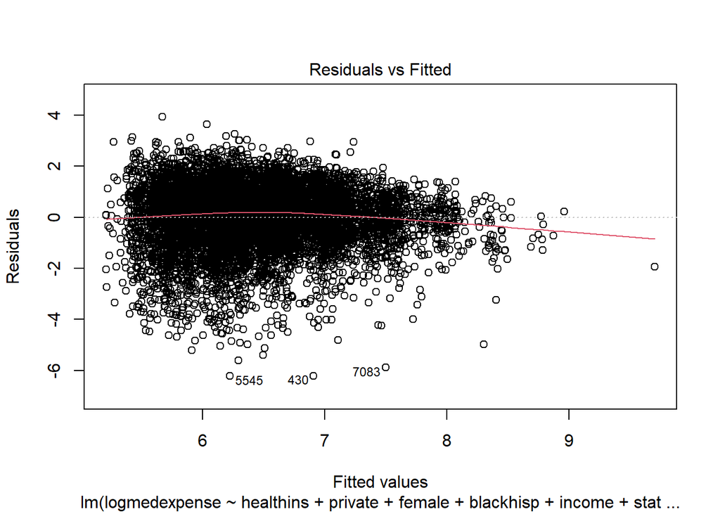

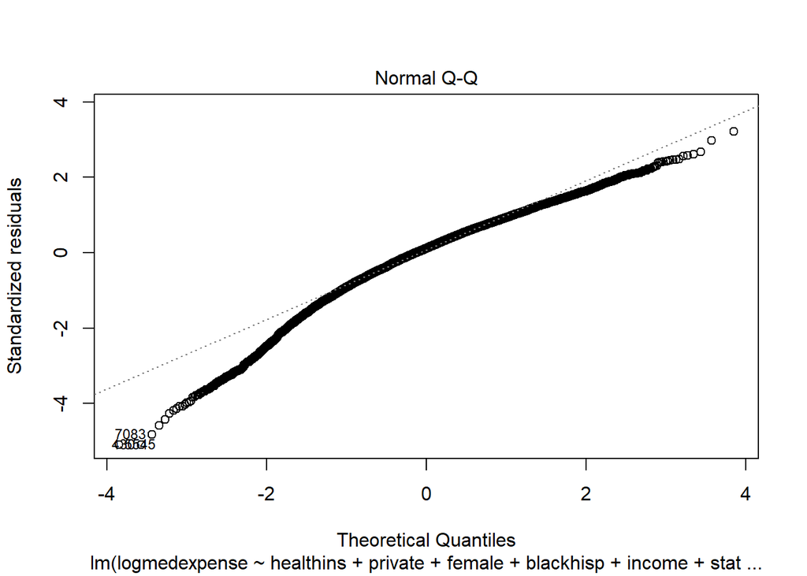

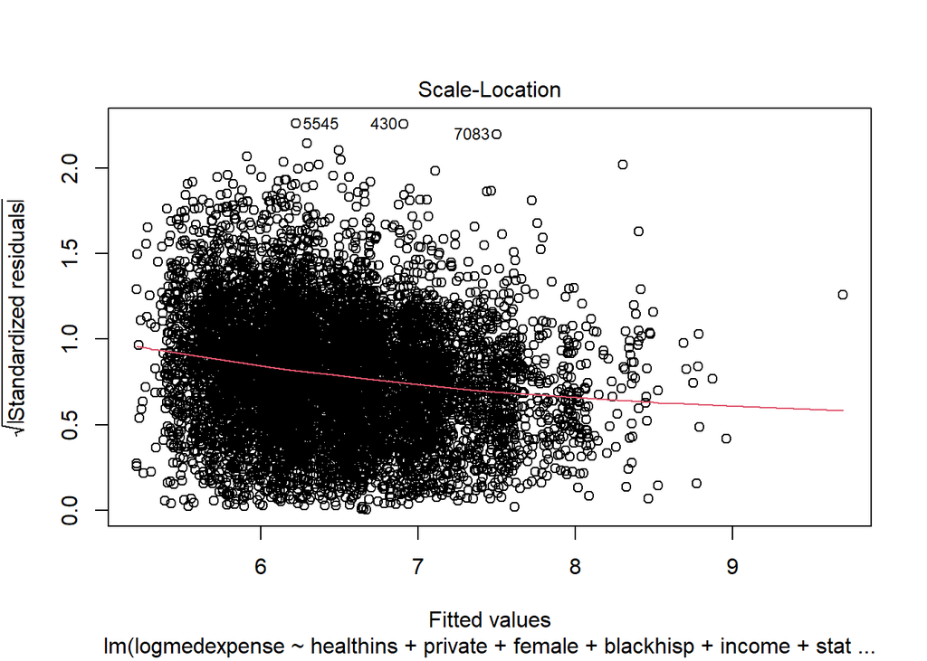

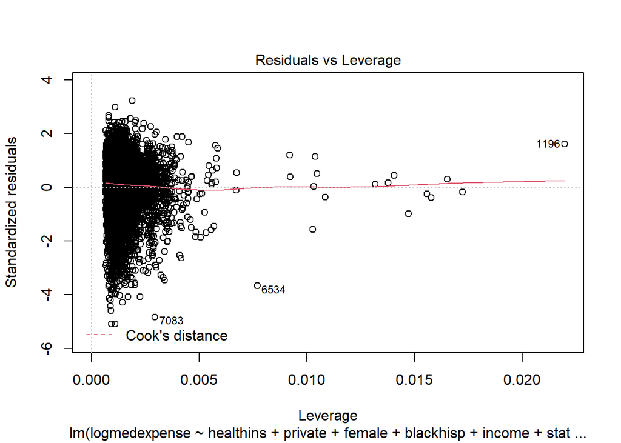

```r
plot(ols_model1)
```

```r
summary(ols_model1, cor=T)
```

```
##
## Call:
## lm(formula = logmedexpense ~ healthins + private + female + blackhisp +
##     income + status + agesqrd + illnesses, data = df)
##
## Residuals:
##     Min      1Q  Median      3Q     Max
## -6.2270 -0.6737  0.1391  0.8449  3.9325
##
## Coefficients:
##                  Estimate Std. Error t value Pr(>|t|)
## (Intercept)     5.965e+00  9.346e-02  63.820  < 2e-16 ***
## healthins1      9.418e-02  3.458e-02   2.724 0.006468 **
## private1        7.353e-04  3.604e-02   0.020 0.983722
## female1         5.846e-02  2.717e-02   2.152 0.031454 *
## blackhisp1     -1.920e-01  3.994e-02  -4.807 1.56e-06 ***
## income          6.300e-04  6.019e-04   1.047 0.295299
## statusgood     -1.485e-01  3.982e-02  -3.730 0.000193 ***
## statuspoor      4.838e-02  6.559e-02   0.738 0.460732
## statusunknown  -4.571e-01  4.812e-02  -9.498  < 2e-16 ***
## statusverygood -2.486e-01  4.201e-02  -5.917 3.40e-09 ***
## agesqrd        -2.019e-05  1.360e-05  -1.485 0.137674
## illnesses       4.073e-01  1.086e-02  37.487  < 2e-16 ***
## ---
## Signif. codes:  0 '***' 0.001 '**' 0.01 '*' 0.05 '.' 0.1 ' ' 1
##
## Residual standard error: 1.222 on 8395 degrees of freedom
## Multiple R-squared:  0.1875, Adjusted R-squared:  0.1864
## F-statistic: 176.1 on 11 and 8395 DF,  p-value: < 2.2e-16
##
## Correlation of Coefficients:
##                (Intercept) healthins1 private1 female1 blackhisp1 income
## healthins1     -0.08
## private1       -0.14       -0.60
## female1        -0.14        0.07      -0.02
## blackhisp1     -0.19       -0.07       0.15     0.01
## income         -0.21       -0.06      -0.03     0.10    0.07
## statusgood     -0.33       -0.02       0.01    -0.02    0.05      -0.04
## statuspoor     -0.15        0.00       0.00     0.02    0.02       0.02
## statusunknown  -0.31       -0.03       0.00    -0.03    0.06      -0.10
## statusverygood -0.34       -0.01      -0.01    -0.05    0.06      -0.07
## agesqrd        -0.85        0.11      -0.02    -0.03    0.09       0.08
## illnesses      -0.22       -0.03       0.00    -0.05    0.00       0.02
##                statusgood statuspoor statusunknown statusverygood agesqrd
## healthins1
## private1
## female1
## blackhisp1
## income
## statusgood
## statuspoor      0.38
## statusunknown   0.57       0.31
## statusverygood  0.65       0.36       0.57
## agesqrd         0.04      -0.01       0.05          0.05
## illnesses       0.13      -0.07       0.21          0.21          -0.05
```

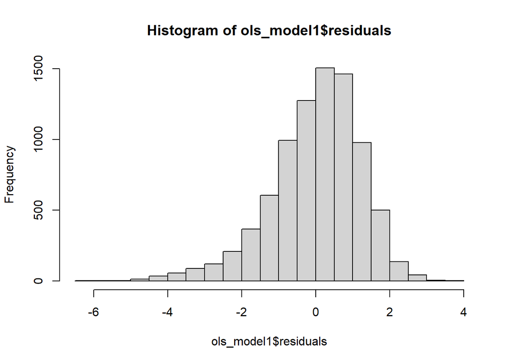

```r
hist(ols_model1$residuals)
```

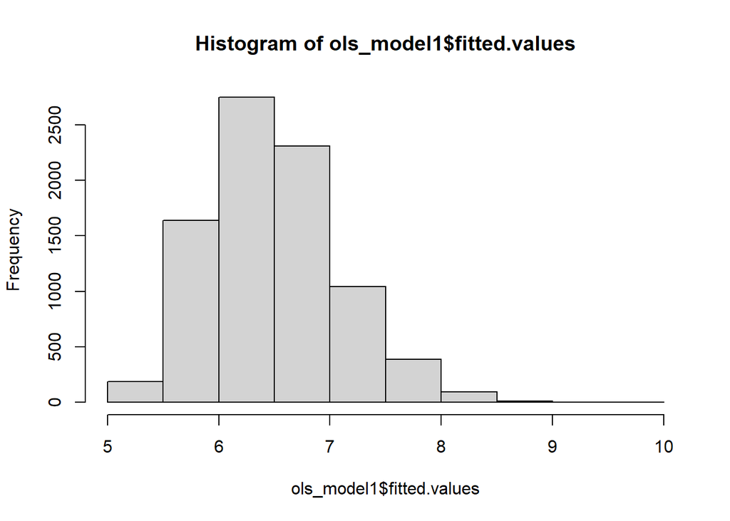

```r
hist(ols_model1$fitted.values)
```

```r
print("Normality - KS test : ") # since sample greather than 2000
```

```
## [1] "Normality - KS test : "
```

```r
norm <- rnorm(8407)
ks.test(norm, ols_model1$res)
```

```
##
##  Two-sample Kolmogorov-Smirnov test
##
## data:  norm and ols_model1$res
## D = 0.058642, p-value = 5.564e-13
## alternative hypothesis: two-sided
```

```r
print("Bartlett's test : ")
```

```
## [1] "Bartlett's test : "
```

```r
bartlett.test(list(ols_model1$residuals,ols_model1$fitted.values))
```

```
##
##  Bartlett test of homogeneity of variances
##
## data:  list(ols_model1$residuals, ols_model1$fitted.values)
## Bartlett's K-squared = 4162.9, df = 1, p-value < 2.2e-16
```

```r
print("Durbin-Watson's test : ")
```

```
## [1] "Durbin-Watson's test : "
```

```r
lmtest::dwtest(ols_model1)
```

```
##
##  Durbin-Watson test
##
## data:  ols_model1
## DW = 1.794, p-value < 2.2e-16
## alternative hypothesis: true autocorrelation is greater than 0
```

```r
car::vif(ols_model1)
```

```
##               GVIF Df GVIF^(1/(2*Df))
## healthins 1.643244  1        1.281891
## private   1.631410  1        1.277267
## female    1.024286  1        1.012070
## blackhisp 1.042947  1        1.021248
## income    1.059811  1        1.029471
## status    1.132274  4        1.015650
## agesqrd   1.047593  1        1.023520
## illnesses 1.105862  1        1.051600
```

The ols model fails to pass the assummptions. Hence the estimates cannot be replied upon. To be specific, it fails the homoscedastic and independene tests.

Trying with weighted least squares as we can see in the residual vs fitted plot, there is fanning inwards for higher values

```r
wt = 1/ols_model1$fitted.values^2
wls <- lm(logmedexpense ~ healthins + private + female + blackhisp + income + status + agesqrd + illnesses,data=df,weights = wt)
summary(wls)
```

```
##
## Call:
## lm(formula = logmedexpense ~ healthins + private + female + blackhisp +
##     income + status + agesqrd + illnesses, data = df, weights = wt)
##
## Weighted Residuals:
##     Min      1Q  Median      3Q     Max
## -0.9969 -0.1035  0.0205  0.1313  0.6974
##
## Coefficients:
##                  Estimate Std. Error t value Pr(>|t|)
## (Intercept)     5.905e+00  9.585e-02  61.605  < 2e-16 ***
## healthins1      1.005e-01  3.535e-02   2.842 0.004491 **
## private1       -9.237e-03  3.665e-02  -0.252 0.801026
## female1         6.321e-02  2.772e-02   2.280 0.022633 *
## blackhisp1     -1.965e-01  4.028e-02  -4.879 1.09e-06 ***
## income          7.204e-04  6.137e-04   1.174 0.240469
## statusgood     -1.487e-01  4.242e-02  -3.506 0.000457 ***
## statuspoor      5.056e-02  7.269e-02   0.696 0.486749
## statusunknown  -4.712e-01  4.903e-02  -9.610  < 2e-16 ***
## statusverygood -2.499e-01  4.406e-02  -5.672 1.46e-08 ***
## agesqrd        -1.465e-05  1.389e-05  -1.055 0.291545
## illnesses       4.246e-01  1.167e-02  36.385  < 2e-16 ***
## ---
## Signif. codes:  0 '***' 0.001 '**' 0.01 '*' 0.05 '.' 0.1 ' ' 1
##
## Residual standard error: 0.1953 on 8395 degrees of freedom
## Multiple R-squared:  0.1786, Adjusted R-squared:  0.1775
## F-statistic: 165.9 on 11 and 8395 DF,  p-value: < 2.2e-16
```

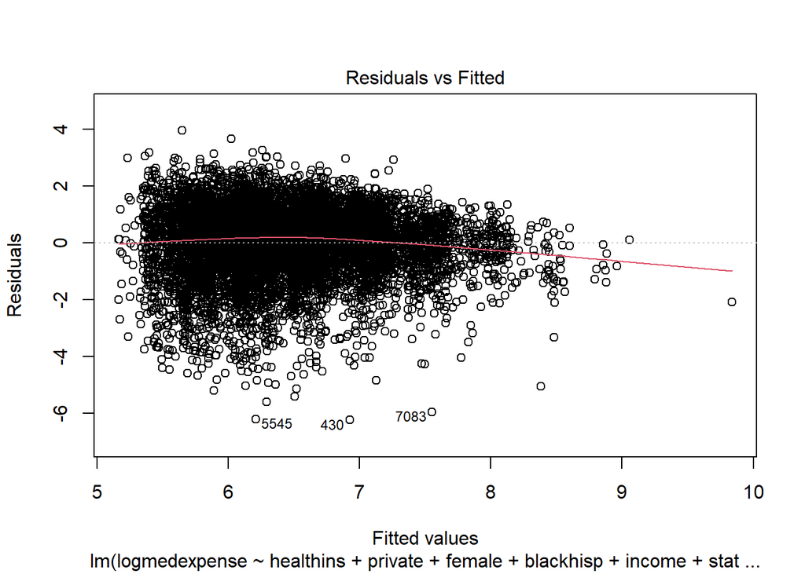

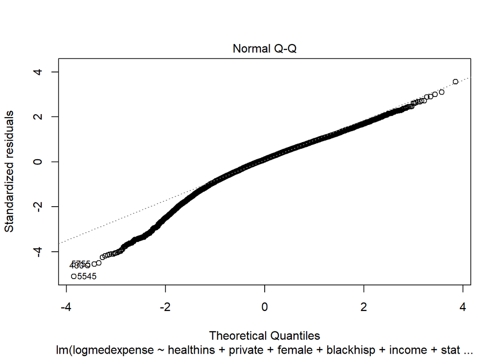

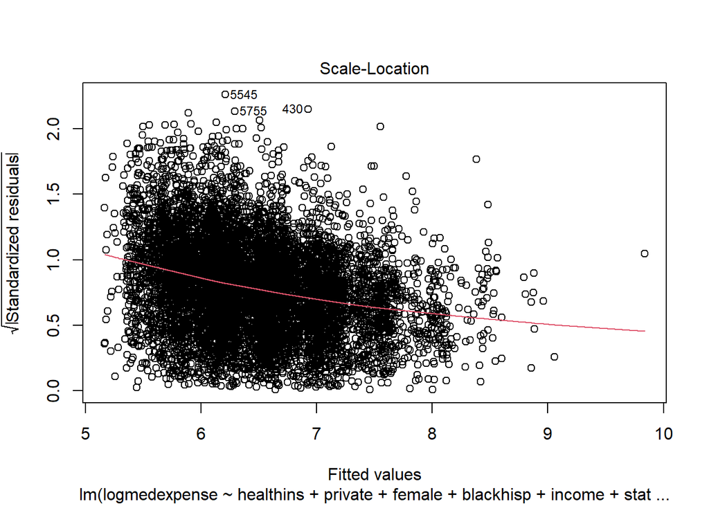

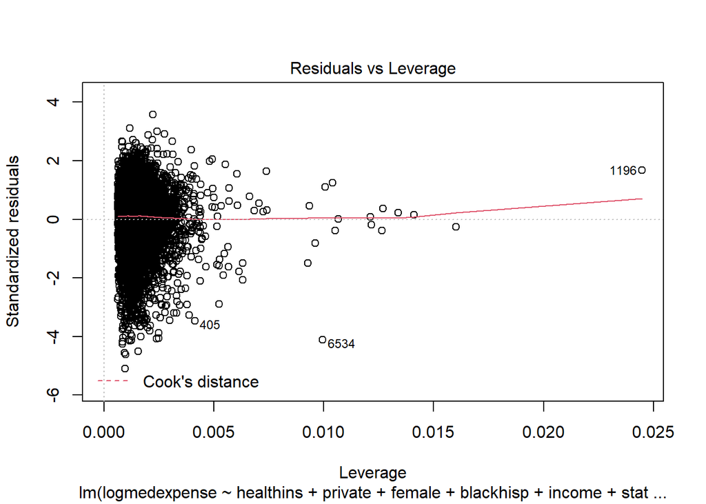

```r
plot(wls)
```

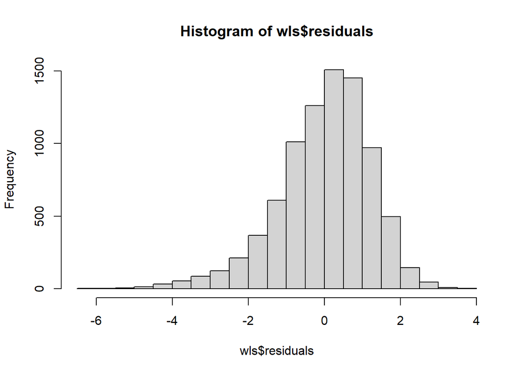

```r
hist(wls$residuals)
```

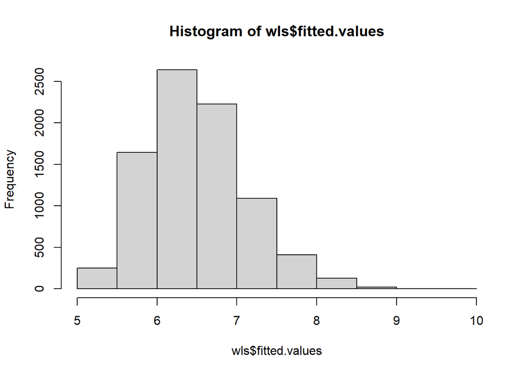

```r
hist(wls$fitted.values)
```

```r
print("Normality - KS test : ") # since sample greather than 2000
```

```
## [1] "Normality - KS test : "
```

```r
norm <- rnorm(8407)
ks.test(norm, wls$res)
```

```
##
##  Two-sample Kolmogorov-Smirnov test
##
## data:  norm and wls$res
## D = 0.061853, p-value = 2.154e-14
## alternative hypothesis: two-sided
```

```r
print("Bartlett's test : ")
```

```
## [1] "Bartlett's test : "
```

```r
bartlett.test(list(wls$residuals,wls$fitted.values))
```

```
##
##  Bartlett test of homogeneity of variances
##
## data:  list(wls$residuals, wls$fitted.values)
## Bartlett's K-squared = 3754.3, df = 1, p-value < 2.2e-16
```

```r
print("Durbin-Watson's test : ")
```

```
## [1] "Durbin-Watson's test : "
```

```r
lmtest::dwtest(ols_model1)
```

```
##
##  Durbin-Watson test
##
## data:  ols_model1
## DW = 1.794, p-value < 2.2e-16
## alternative hypothesis: true autocorrelation is greater than 0
```

```r
car::vif(wls)
```

```
##               GVIF Df GVIF^(1/(2*Df))
## healthins 1.635597  1        1.278905
## private   1.626472  1        1.275332
## female    1.023701  1        1.011781
## blackhisp 1.045875  1        1.022680
## income    1.061052  1        1.030074
## status    1.124270  4        1.014749
## agesqrd   1.048564  1        1.023994
## illnesses 1.097537  1        1.047634
```

```r
ols_model2 <- lm(logmedexpense ~ private + female + blackhisp + ssiratio + illnesses + agesqrd ,data=df)
summary(ols_model2)
```

```
##
## Call:
## lm(formula = logmedexpense ~ private + female + blackhisp + ssiratio +
##     illnesses + agesqrd, data = df)
##
## Residuals:
##     Min      1Q  Median      3Q     Max
## -6.3374 -0.6835  0.1484  0.8441  3.5702
##
## Coefficients:
##               Estimate Std. Error t value Pr(>|t|)
## (Intercept)  5.692e+00  8.345e-02  68.206  < 2e-16 ***
## private1     6.334e-02  2.883e-02   2.197 0.028057 *
## female1      3.404e-02  2.712e-02   1.255 0.209384
## blackhisp1  -1.549e-01  3.989e-02  -3.884 0.000104 ***
## ssiratio     1.946e-01  4.461e-02   4.363  1.3e-05 ***
## illnesses    4.355e-01  1.046e-02  41.655  < 2e-16 ***
## agesqrd     -2.558e-05  1.366e-05  -1.872 0.061209 .
## ---
## Signif. codes:  0 '***' 0.001 '**' 0.01 '*' 0.05 '.' 0.1 ' ' 1
##
## Residual standard error: 1.229 on 8400 degrees of freedom
## Multiple R-squared:  0.178,  Adjusted R-squared:  0.1774
## F-statistic: 303.2 on 6 and 8400 DF,  p-value: < 2.2e-16
```

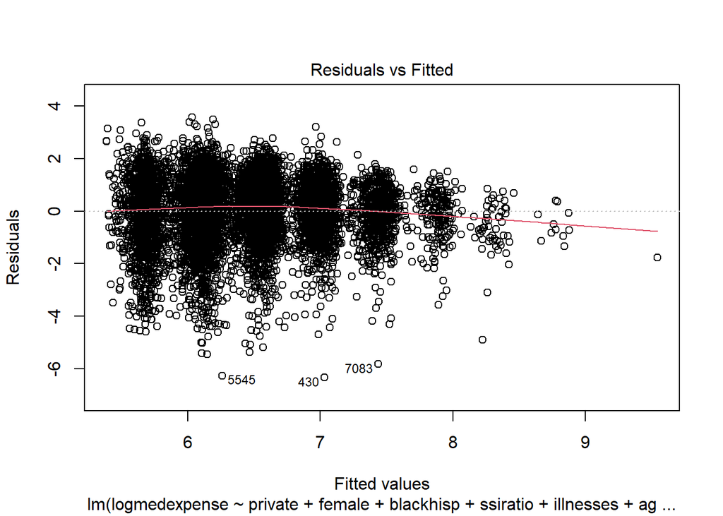

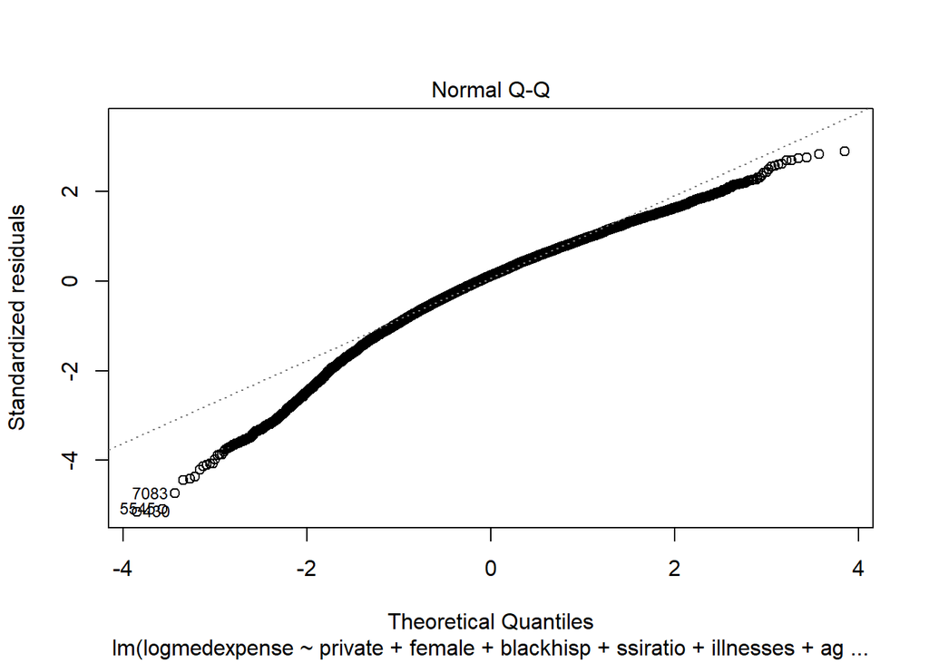

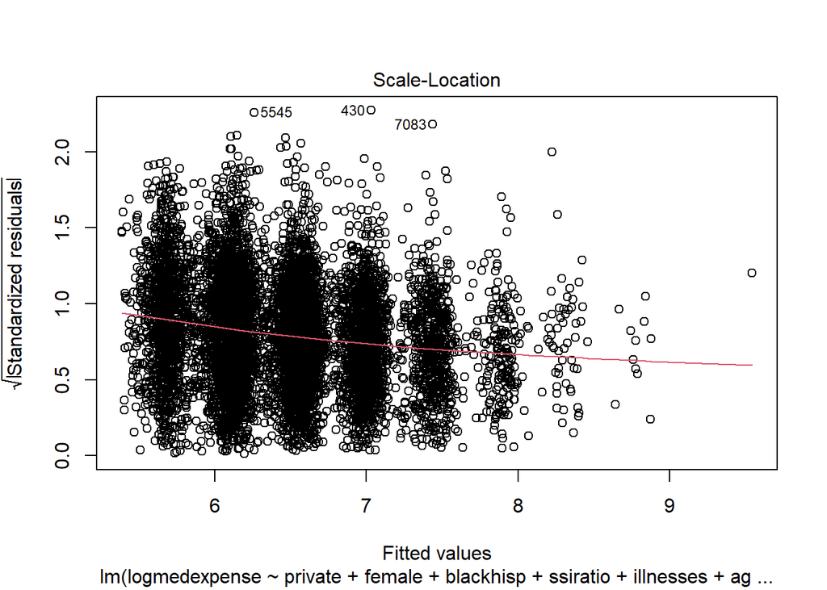

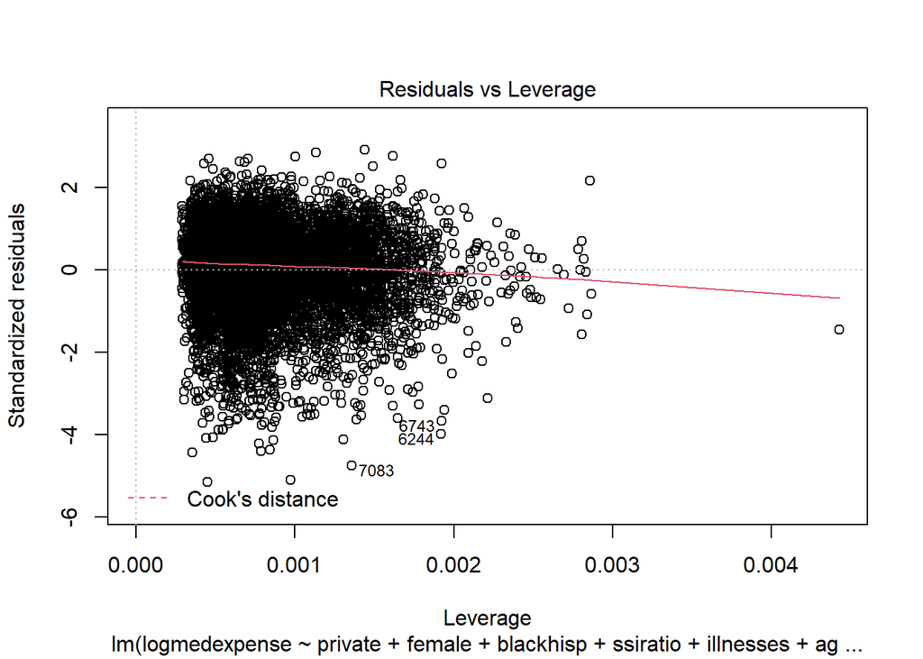

```r
plot(ols_model2)
```

```r
summary(ols_model2, cor=T)
```

```
##
## Call:
## lm(formula = logmedexpense ~ private + female + blackhisp + ssiratio +
##     illnesses + agesqrd, data = df)
##
## Residuals:
##     Min      1Q  Median      3Q     Max
## -6.3374 -0.6835  0.1484  0.8441  3.5702
##
## Coefficients:
##               Estimate Std. Error t value Pr(>|t|)
## (Intercept)  5.692e+00  8.345e-02  68.206  < 2e-16 ***
## private1     6.334e-02  2.883e-02   2.197 0.028057 *
## female1      3.404e-02  2.712e-02   1.255 0.209384
## blackhisp1  -1.549e-01  3.989e-02  -3.884 0.000104 ***
## ssiratio     1.946e-01  4.461e-02   4.363  1.3e-05 ***
## illnesses    4.355e-01  1.046e-02  41.655  < 2e-16 ***
## agesqrd     -2.558e-05  1.366e-05  -1.872 0.061209 .
## ---
## Signif. codes:  0 '***' 0.001 '**' 0.01 '*' 0.05 '.' 0.1 ' ' 1
##
## Residual standard error: 1.229 on 8400 degrees of freedom
## Multiple R-squared:  0.178,  Adjusted R-squared:  0.1774
## F-statistic: 303.2 on 6 and 8400 DF,  p-value: < 2.2e-16
##
## Correlation of Coefficients:
##            (Intercept) private1 female1 blackhisp1 ssiratio illnesses
## private1   -0.31
## female1    -0.14        0.03
## blackhisp1 -0.18        0.14     0.00
## ssiratio   -0.08        0.08    -0.06    0.03
## illnesses  -0.14       -0.02    -0.04   -0.03      -0.07
## agesqrd    -0.88        0.06    -0.03    0.09      -0.16    -0.07
```

```r
ols_model1 %>% vcov %>% diag() %>% sqrt() %>% round(3)
```

```
##    (Intercept)     healthins1       private1        female1     blackhisp1
##          0.093          0.035          0.036          0.027          0.040
##         income     statusgood     statuspoor  statusunknown statusverygood
##          0.001          0.040          0.066          0.048          0.042
##        agesqrd      illnesses
##          0.000          0.011
```

```r
stargazer::stargazer(ols_model1,wls,ols_model2, title="Results", type = "text")
```

```
##
## Results
## ===================================================================================================
##                                                   Dependent variable:
##                     -------------------------------------------------------------------------------
##                                                      logmedexpense
##                                (1)                        (2)                        (3)
## ---------------------------------------------------------------------------------------------------
## healthins1                   0.094***                   0.100***
##                              (0.035)                    (0.035)
##
## private1                      0.001                      -0.009                    0.063**
##                              (0.036)                    (0.037)                    (0.029)
##
## female1                      0.058**                    0.063**                     0.034
##                              (0.027)                    (0.028)                    (0.027)
##
## blackhisp1                  -0.192***                  -0.197***                  -0.155***
##                              (0.040)                    (0.040)                    (0.040)
##
## income                        0.001                      0.001
##                              (0.001)                    (0.001)
##
## statusgood                  -0.148***                  -0.149***
##                              (0.040)                    (0.042)
##
## statuspoor                    0.048                      0.051
##                              (0.066)                    (0.073)
##
## statusunknown               -0.457***                  -0.471***
##                              (0.048)                    (0.049)
##
## statusverygood              -0.249***                  -0.250***
##                              (0.042)                    (0.044)
##
## ssiratio                                                                          0.195***
##                                                                                    (0.045)
##
## agesqrd                      -0.00002                   -0.00001                  -0.00003*
##                             (0.00001)                  (0.00001)                  (0.00001)
##
## illnesses                    0.407***                   0.425***                  0.436***
##                              (0.011)                    (0.012)                    (0.010)
##
## Constant                     5.965***                   5.905***                  5.692***
##                              (0.093)                    (0.096)                    (0.083)
##
## ---------------------------------------------------------------------------------------------------
## Observations                  8,407                      8,407                      8,407
## R2                            0.188                      0.179                      0.178
## Adjusted R2                   0.186                      0.178                      0.177
## Residual Std. Error     1.222 (df = 8395)          0.195 (df = 8395)          1.229 (df = 8400)
## F Statistic         176.136*** (df = 11; 8395) 165.946*** (df = 11; 8395) 303.168*** (df = 6; 8400)
## ===================================================================================================
## Note:                                                                   *p<0.1; **p<0.05; ***p<0.01
```

Inferences made from the best model which is the weighted model:

• Do people with health insurance have higher or lower medical expense than people without health insurance, when other variables are controlled? By how much? Why do you think this happens? The marginal effect of health insurance suggests that people with health insurance will likely pay 10% more than people without health insurances on medical expenses ie while keeping all other variables constant. This could be possible because insurances do not cover everything like long-term care, dental, eye exams etc, even medicare does not cover these.

• Do people with private insurance pay more or less than people with public insurance? By how much? The marginal effect of private insurance suggests that people with private insurance spend 1% lesser than people with public insurance while keeping all other variables constant.

• Do people with more illnesses have higher or lower medical expense than people with less illnesses? By how much? The marginal effect of illnesses suggests that if the number of illnesses increases by 1 then medical expense would go up by 52% keeping all other variables constant.

• Do older people have higher medical expense than younger people? By how much? The dataset does not have information on younger people.

• Do minority groups (Blacks/Hispanics) have higher or lower medical expenses than the non-minority population? By how much? The marginal effect of blackhisp suggests that minority groups (Blacks/Hispanics) spend 18% less on medical expenses than non-minority groups while keeping all other variables constant.

• How do people’s income level relate to their medical expense, when controlled for other factors? By how much? The marginal effect of income suggests that if annual income increases by $1000 then medical expenses would go up by 0.1% keeping all other variables constant